# **Final Project: R Report - Data Analysis**

Catherine Shea

2022-12-16

## **Data Exploration**

### Numerical Exploration

**Create a code chunk that includes the following:**

- Use summary() on the body mass and body length data columns in the Delomys data set to display summary statistics.
- Perform a test of normality on the body mass and length columns. You can use shapiro.test()

Summary of Delomys Body Mass

```
##    Min. 1st Qu.  Median    Mean 3rd Qu.    Max.
##    5.00   35.00   43.00   44.06   54.00  105.00
```

Summary of Delomys Body Length

```
##    Min. 1st Qu.  Median    Mean 3rd Qu.    Max.
##    49.0   106.0   116.0   114.7   124.0   265.0
```

Shapiro Test of Normality between Delomys Body Mass and Length

```
##
##  Shapiro-Wilk normality test
##
## data:  delomys$body_mass[delomys$body_length]
## W = 0.9428, p-value < 2.2e-16
```

### Graphical Exploration

[figure not shown]

**Using code chunks, create the following plots, which you’ll use to answer the report questions:**

- A scatterplot of body mass and body length
- A histogram of body mass
- A histogram of body length
- A conditional boxplot of body mass, conditioned on species (column binomial)
- A conditional boxplot of body mass, conditioned on sex (column sex)
- A conditional boxplot of body mass, conditioned on both species and sex

You will need to experiment with different width, height, and/or aspect values for each of your figures.

[figure not shown]

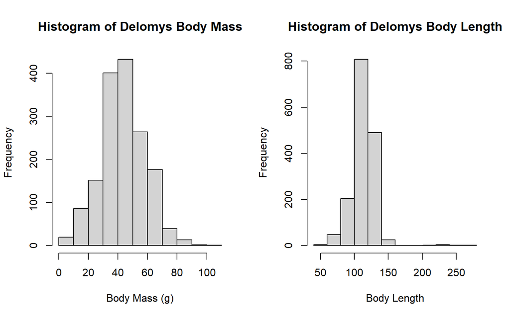

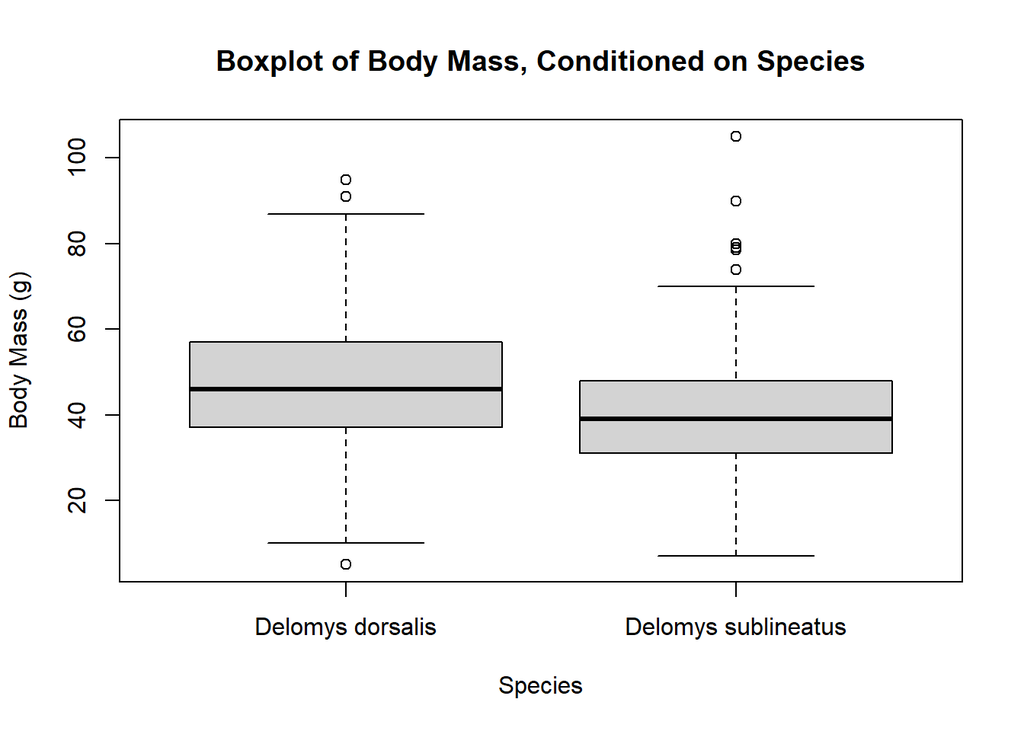

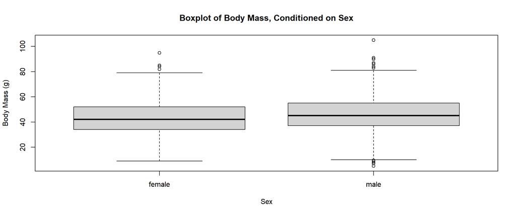

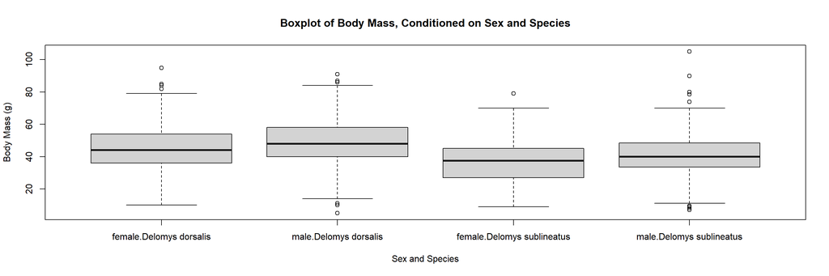

### Data Exploration

**Q1 (2 pts.): Qualitatively describe the relationship between body mass and length.**

> Does the relationship seem linear, curved, nonexistent?

Delomys body mass and length seem to share a positive linear relationship, marked by the scatterplot indication of an increase in body length as body mass increases.

**Q2 (2 pts.): Qualitatively describe the shapes of the histograms.**

> Do the data appear normally-distributed? Explain why or why not.

> Explain why we care (or not) whether the data are normally distributed.

This information from the histograms indicate that: * In a range of body mass values ~0-120 grams, the majority of the delomys sample have a body mass between ~30-70 grams. * In a range of body length values between ~40-275 mm, the majority of the deolmys sample have a body mass between ~80-140 mm.

**Q3 (2 pts.): Using both the histograms and normality tests, do you think the (unconditioned) body masses and body length are normally-distributed?**

> Make sure you contrast your visual assessment of normality to the results of the numerical normality tests.

```
##
##  Shapiro-Wilk normality test
##
## data:  delomys$body_mass
## W = 0.99506, p-value = 4.33e-05
```

```
##
##  Shapiro-Wilk normality test
##
## data:  delomys$body_length
## W = 0.87609, p-value < 2.2e-16
```

**Q4 (2 pts.): Examine the three conditional boxplots.**

> Describe any graphical evidence you see for body mass differences based on species and/or sex.

In the conditional boxplot between body mass and species, delomys dorsalis has a noticably higher body mass than the delomys sublineatus species.

In the conditional boxplot between body mass and sex, the body mass difference between males and females is close to the same, but with a slightly higher value in male delomys.

In the conditional boxplot for body mass conditioned by both sex and species, the male delomys dorsalis has the highest body mass overall. The female delomys dorsalis has the second highest, being greater than both the male and female delomys sublineatus species. In both species, the male dorsalis body mass is slightly greater than the female body mass – however, the delomys dorsalis overall has a greater body mass than sublineatus.

### Model Assumptions

**Using a code chunk, fit 5 models using lm():**

Model 1: simple linear regression body_length ~ body_mass Model 2: 1-way ANOVA body_mass ~ sex Model 3: 1-way ANOVA body_mass ~ binomial Model 4: 2-way additive ANOVA body_mass ~ sex + binomial Model 5: 2-way factorial ANOVA body_mass ~ sex * binomial

```
##
## Call:
## lm(formula = body_length ~ body_mass, data = delomys)
##
## Coefficients:
## (Intercept)    body_mass
##     76.1247       0.8755
```

|  | Df | Sum Sq | Mean Sq | F value | Pr(>F) |
| --- | --- | --- | --- | --- | --- |
| sex | 1 | 3061.678 | 3061.6779 | 13.94294 | 0.0001951 |
| Residuals | 1578 | 346507.131 | 219.5863 | NA | NA |

|  | Df | Sum Sq | Mean Sq | F value | Pr(>F) |
| --- | --- | --- | --- | --- | --- |
| binomial | 1 | 21289.68 | 21289.6805 | 102.0751 | 0 |
| Residuals | 1583 | 330164.45 | 208.5688 | NA | NA |

|  | Df | Sum Sq | Mean Sq | F value | Pr(>F) |
| --- | --- | --- | --- | --- | --- |
| sex | 1 | 3061.678 | 3061.6779 | 14.95838 | 0.0001144 |
| binomial | 1 | 23727.134 | 23727.1342 | 115.92320 | 0.0000000 |
| Residuals | 1577 | 322779.997 | 204.6798 | NA | NA |

|  | Df | Sum Sq | Mean Sq | F value | Pr(>F) |
| --- | --- | --- | --- | --- | --- |
| sex | 1 | 3.061678e+03 | 3.061678e+03 | 14.948932 | 0.0001150 |
| binomial | 1 | 2.372713e+04 | 2.372713e+04 | 115.849977 | 0.0000000 |
| sex:binomial | 1 | 7.913846e-01 | 7.913846e-01 | 0.003864 | 0.9504424 |
| Residuals | 1576 | 3.227792e+05 | 2.048091e+02 | NA | NA |

**Q5 (2 pts.): What do you conclude about residual normality based on the numerical and graphical diagnostics?**

> **Q6 (1 pt.): Are violations of the normality assumption equally severe for all the models?**

### Model Interpretation

|  | Estimate | Std. Error | t value | Pr(>\|t\|) |
| --- | --- | --- | --- | --- |
| (Intercept) | 76.1246565 | 0.9158120 | 83.12258 | 0 |
| body_mass | 0.8754988 | 0.0196905 | 44.46298 | 0 |

**Q7 (2 pts.): What is the magnitude of the mass/length relationship?**

The magnitude of the mass/length relationship is 0.87550g.

**Q8 (2 pts.): What is the expected body length of an animal that weighs 100g?**

The expected body length of an animal that weighs 100g equals: 0.87550(100) + 76.12466 = 163.67466mm.

**Q9 (2 pts.): What is the expected body length of an animal that weighs 0g?**

The expected body length of an animal that weighs 0 grams is 76.12466mm.

### Body Mass: Coefficient Tables

**Q10 (1 pt.): What is the base level for sex?**

The base level for sex is female.

|  | Estimate | Std. Error | t value | Pr(>\|t\|) |
| --- | --- | --- | --- | --- |
| (Intercept) | 42.711465 | 0.5288929 | 80.756355 | 0.0000000 |
| sexmale | 2.784133 | 0.7456117 | 3.734024 | 0.0001951 |

|  | Estimate | Std. Error | t value | Pr(>\|t\|) |
| --- | --- | --- | --- | --- |
| (Intercept) | 46.752427 | 0.4499933 | 103.89582 | 0 |
| binomialDelomys sublineatus | -7.683058 | 0.7604562 | -10.10322 | 0 |

|  | Estimate | Std. Error | t value | Pr(>\|t\|) |
| --- | --- | --- | --- | --- |
| (Intercept) | 45.070355 | 0.5556429 | 81.113891 | 0e+00 |
| sexmale | 3.795395 | 0.7259609 | 5.228099 | 2e-07 |
| binomialDelomys sublineatus | -8.193492 | 0.7609985 | -10.766764 | 0e+00 |

|  | Estimate | Std. Error | t value | Pr(>\|t\|) |
| --- | --- | --- | --- | --- |
| (Intercept) | 45.0554562 | 0.6052973 | 74.4352459 | 0.0000000 |
| sexmale | 3.8280908 | 0.8966667 | 4.2692460 | 0.0000208 |
| binomialDelomys sublineatus | -8.1417394 | 1.1281046 | -7.2171847 | 0.0000000 |
| sexmale:binomialDelomys sublineatus | -0.0950187 | 1.5285856 | -0.0621612 | 0.9504424 |

**Q11 (1 pt.): What is the base level for binomial?**

The base level for binomial is Delomys Dorsalis.

**Q12 (1 pt.): Which sex is heavier? How do you know?**

> **Q13 (1 pt.): Which species is heavier? How do you know?**

### ANOVA Tables

Fit 2

|  | Df | Sum Sq | Mean Sq | F value | Pr(>F) |
| --- | --- | --- | --- | --- | --- |
| sex | 1 | 3061.678 | 3061.6779 | 13.94294 | 0.0001951 |
| Residuals | 1578 | 346507.131 | 219.5863 | NA | NA |

Fit 3

|  | Df | Sum Sq | Mean Sq | F value | Pr(>F) |
| --- | --- | --- | --- | --- | --- |
| binomial | 1 | 21289.68 | 21289.6805 | 102.0751 | 0 |
| Residuals | 1583 | 330164.45 | 208.5688 | NA | NA |

Fit 4

|  | Df | Sum Sq | Mean Sq | F value | Pr(>F) |
| --- | --- | --- | --- | --- | --- |
| sex | 1 | 3061.678 | 3061.6779 | 14.95838 | 0.0001144 |
| binomial | 1 | 23727.134 | 23727.1342 | 115.92320 | 0.0000000 |
| Residuals | 1577 | 322779.997 | 204.6798 | NA | NA |

Fit 5

|  | Df | Sum Sq | Mean Sq | F value | Pr(>F) |
| --- | --- | --- | --- | --- | --- |
| sex | 1 | 3.061678e+03 | 3.061678e+03 | 14.948932 | 0.0001150 |
| binomial | 1 | 2.372713e+04 | 2.372713e+04 | 115.849977 | 0.0000000 |
| sex:binomial | 1 | 7.913846e-01 | 7.913846e-01 | 0.003864 | 0.9504424 |
| Residuals | 1576 | 3.227792e+05 | 2.048091e+02 | NA | NA |

**Q14 (1 pt.): Are sex and species significant predictors for body mass?**

**Q15 (1 pt.): Is there a significant interaction?**

There is not a significant interaction between sex and species against body mass, as the interactive model (Fit_5) has a p-value (Pr(>F)) of 0.9504424.

**Q16 (2 pts.): Examine the p-values for the main effects (sex and species) in all four of the ANOVA tables.**

> Does the significance level of either main effect change very much among the different models?

The significance level does not significantly change between the 1-sided ANOVA p-values for sex (0.0001951) or for binomial (0) when shifted to two-way additive or interactive ANOVA models, fit 4(sex = 0.0001144,binomial = 0), fit 5(sex = 0.0001150, binomial = 0). The only major difference is within the sex:binomial relationship, where the p-value = 0.9504424.

## Model Comparison: Body Mass

### Model Comparison

```
## [1] 13006.8
```

```
## [1] 12966.36
```

```
## [1] 12896.73
```

```
## [1] 12898.72
```

**Q17 (1 pt.): Which two models have the lowest AIC?**

**Q18 (4 pts.): Which of the two models with lowest AIC scores would you select?**

I would select fit 4, as it has the lowest overall AIC value.

> Explain your decision based on model fit and the complexity/understanding tradeoff.